# Analyzing Wind Speed, Humidity, and Temperature Trends and Their Impact on Precipitation

```python
import requests
from datetime import datetime, timedelta
import pandas as pd
import numpy as np
import geopandas as gpd
from shapely.geometry import Point
import matplotlib.pyplot as plt
import matplotlib.cm as cm
import matplotlib.colors as mcolors
import contextily as ctx
import osmnx as ox
import os
```

## Introduction, Context and Short literature review on the problem

Windspeed and precipitation patterns are intricately tied to atmospheric dynamics. The Earth’s atmosphere is mainly driven by solar heating, with the equator receiving the most direct sunlight. This causes the air to warm and rise, creating a low-pressure zone, while cooler, denser air at the poles forms high-pressure areas. The rotation of the Earth causes air to accumulate around 30° latitude, creating high-pressure belts. On the other hand surface winds are influenced by friction with the Earth’s terrain, which alters their speed and direction, causing them to cross isobars and flow toward low-pressure zones.

Humidity plays a crucial role in weather and climate, influencing cloud formation, storm development, and precipitation. At 100% relative humidity, the air reaches its maximum moisture-holding capacity at a given temperature. However, this does not guarantee precipitation, as other factors like atmospheric pressure, temperature, and condensation nuclei are also essential for precipitation. Even when the air is saturated, conditions like fog can form without rain, and rainfall can occur even if surface humidity is below 100%.

Wind patterns and humidity are critical in understanding weather events such as storms and wind-driven disasters. Strong winds, particularly during winter windstorms, have significant implications for various sectors, including construction and transportation. The precision of wind speed measurements is vital for forecasting, and areas with frequent strong winds tend to have more resilient infrastructure absence of which can lead to higher costs of repairs, longer recovery times, and increased risks during future storms. In addition, changes in rainfall during dry seasons can lead to soil erosion and agricultural productivity leading to economic strain which highlights the importance of understanding and predicting these complex atmospheric interactions.

```python
# Reading Shape File
shapefile_path = '/Users/avanimahawar/Desktop/ENVS456/assignments/Local_Authority_Districts_May_2024_Boundaries_UK_BFE_-5758551109064458912/LAD_MAY_2024_UK_BFE.shp'

# Load the shapefile
gdf = gpd.read_file(shapefile_path)
```

## API Functioning

Since I am using an API to get the data for both my static and interactive maps, I will explain this part first. I am fetching the data from Windy.com’s Meteoblue, which offers forecasts and current weather data in their basic free package. There is a forecast API that provides data for temperature, wind speed, precipitation, and humidity for every latitude and longitude that you pass in the URL, along with its token key. I used a shapefile from the Office for National Statistics with local authority districts. It shares the administrative boundaries of the United Kingdom as of May 2024. Once the shapefile was imported, it was read using the Geopandas library. Then, the city, latitude, and longitude columns were used to iterate over the URL in our API. I am using the latitude and longitude from our shapefile to loop over the Meteoblue forecast API. Once the API call is done, the data is appended to the same dataframe (gdf) from our shapefile to create static maps.

```python
# Api call code
API_KEY = 'GaXxgwYFKDJ9mMV2'

# Loop over each row in the GeoDataFrame (gdf)
for idx, row in gdf.iterrows():
    city = row['LAD24NM']  # City name
    lat = row['LAT']  # Latitude
    lon = row['LONG']  # Longitude

    # URL for the API call
    url = f"https://my.meteoblue.com/packages/basic-day?lat={lat}&lon={lon}&apikey={API_KEY}"

    # Send the request
    try:
        response = requests.get(url)
        response.raise_for_status()  # Raise an exception for non-200 status codes


        data = response.json()
        if 'data_day' in data:
            data_day = data['data_day']
            temperature_instant = data_day['temperature_instant'][0] if len(data_day['temperature_instant']) > 0 else None
            precipitation = data_day['precipitation'][0] if len(data_day['precipitation']) > 0 else None
            windspeed = data_day['windspeed_mean'][0] if len(data_day['windspeed_mean']) > 0 else None
            humidity = data_day['humiditygreater90_hours'][0] if len(data_day['humiditygreater90_hours']) > 0 else None

            # Add the fetched data to the GeoDataFrame
            gdf.at[idx, 'temperature'] = temperature_instant
            gdf.at[idx, 'precipitation'] = precipitation
            gdf.at[idx, 'windspeed'] = windspeed
            gdf.at[idx, 'humidity'] = humidity
        else:
            # No 'data_day' found
            pass
    except requests.exceptions.RequestException as e:

        pass

# Print a summary of the updates to the GeoDataFrame
print(f"Weather data has been added to the GeoDataFrame with {len(gdf)} rows.")
```

```
Weather data has been added to the GeoDataFrame with 361 rows.
```

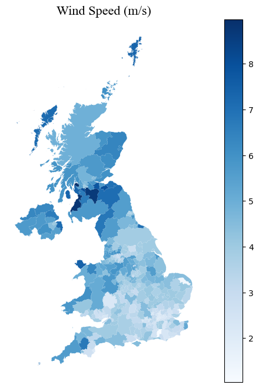

```python
fig, ax = plt.subplots(1, 1, figsize=(10,8))
gdf.plot(ax = ax, column = 'windspeed', linewidth = 0.3, cmap = 'Blues', legend = True)
ax.set_axis_off()
title_parameters = {'fontsize':'16', 'fontname':'Times New Roman'}
ax.set_title("Wind Speed (m/s)", **title_parameters)
```

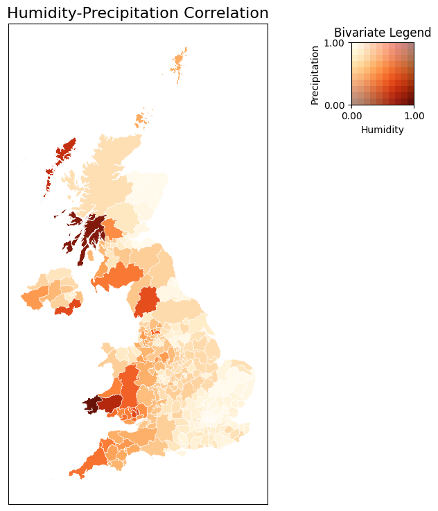

```python
# Bivariate choropleth map
cmap_humidity = plt.cm.Reds  # Red shades for humidity
cmap_precip = plt.cm.YlOrBr  # Yellow to brown for precipitation

# Normalize both humidity and precipitation values together for balanced color mapping
gdf['humidity_norm'] = (gdf['humidity'] - gdf['humidity'].min()) / (gdf['humidity'].max() - gdf['humidity'].min())
gdf['precip_norm'] = (gdf['precipitation'] - gdf['precipitation'].min()) / (gdf['precipitation'].max() - gdf['precipitation'].min())

# Function to blend two colormaps
def bivariate_cmap(c1, c2, n=256):
    return mcolors.ListedColormap(
        [
            np.array(mcolors.to_rgba(c1(i / (n - 1)))[:3]) * 0.5 +
            np.array(mcolors.to_rgba(c2(i / (n - 1)))[:3]) * 0.5
            for i in range(n)
        ]
    )

# Create a bivariate colormap by blending the two colormaps
bivariate_cmap = bivariate_cmap(cmap_humidity, cmap_precip)

# Plotting
fig, ax = plt.subplots(1, 1, figsize=(9, 9))

# Plot the combined normalized values to ensure full color coverage
gdf['combined_norm'] = (gdf['humidity_norm'] + gdf['precip_norm']) / 2
gdf['combined_norm'].fillna(0, inplace=True)  # Handle NaN values by assigning minimum color

# Plot the GeoDataFrame with the bivariate colormap
gdf.plot(ax=ax,
         column='combined_norm',
         cmap=bivariate_cmap,
         linewidth=0.3,
         edgecolor='white',
         legend=False)

# Set title and remove axis labels
ax.set_title("Humidity-Precipitation Correlation", fontsize=16)
ax.set_xticks([])
ax.set_yticks([])

# Create a bivariate legend on the side of the map
fig.subplots_adjust(right=0.85)
ax_leg = fig.add_axes([0.83, 0.75, 0.1, 0.1])  # Position the legend

grid_size = 10  # Defines resolution of legend
grid = np.zeros((grid_size, grid_size, 3))
for i in range(grid_size):
    for j in range(grid_size):
        color = (
            np.array(mcolors.to_rgba(cmap_humidity(i / (grid_size - 1)))[:3]) * 0.5 +
            np.array(mcolors.to_rgba(cmap_precip(j / (grid_size - 1)))[:3]) * 0.5
        )
        grid[j, i] = color

# Display the bivariate legend as an image
ax_leg.imshow(grid, aspect='auto', extent=[gdf['humidity_norm'].min(), gdf['humidity_norm'].max(), gdf['precip_norm'].min(), gdf['precip_norm'].max()])
ax_leg.set_xlabel("Humidity")
ax_leg.set_ylabel("Precipitation")
ax_leg.set_xticks([gdf['humidity_norm'].min(), gdf['humidity_norm'].max()])
ax_leg.set_yticks([gdf['precip_norm'].min(), gdf['precip_norm'].max()])
ax_leg.set_xticklabels([f"{gdf['humidity_norm'].min():.2f}", f"{gdf['humidity_norm'].max():.2f}"])
ax_leg.set_yticklabels([f"{gdf['precip_norm'].min():.2f}", f"{gdf['precip_norm'].max():.2f}"])
ax_leg.set_title("Bivariate Legend")
ax_leg.grid(False)

# Display the map
plt.show()
```

## Data Sources Presentation

For this project, the primary data source is Meteoblue, accessed via an API that provides weather forecasts and current data, including temperature, wind speed, precipitation, and humidity. Meteoblue’s weather models simulate physical atmospheric processes by dividing regions into small grid cells, each approximately 4 km to 40 km wide and 100 m to 2 km high. These models feature 60 vertical atmospheric layers, reaching up to 60 km into the stratosphere. Weather is simulated every few seconds by solving complex mathematical equations between the grid cells, storing weather variables like temperature, wind speed, and cloudiness every hour. Meteoblue operates proprietary models based on NMM (Nonhydrostatic Meso-Scale Modelling) technology and integrates open data from various sources. The models are run twice daily on a dedicated High Performance Cluster, generating forecasts for large domains covering parts of continents. These domains are embedded within global models, providing boundary conditions for the forecasts. Each grid cell considers specific factors like position, altitude, and land surface type, ensuring high-quality weather forecasting for locations ranging from city centers to remote mountain areas. I used Meteoblue’s free package to fetch data for the United Kingdom, and the geographic data was sourced from a shapefile provided by the Office for National Statistics. The data was processed using Geopandas and Matplotlib, allowing for the creation of static maps to visualize regional weather patterns.

## Interactive Map Functioning and Design Choices (Temperature Variation Current V/S T+5 Days)

```python
# List of 100 cities from the UK with their latitudes and longitudes
cities = [
    {'city': 'London', 'lat': 51.5074, 'lon': -0.1278},
    {'city': 'Birmingham', 'lat': 52.4862, 'lon': -1.8904},
    {'city': 'Manchester', 'lat': 53.4808, 'lon': -2.2426},
    {'city': 'Leeds', 'lat': 53.8008, 'lon': -1.5491},
    {'city': 'Glasgow', 'lat': 55.8642, 'lon': -4.2518},
    {'city': 'Sheffield', 'lat': 53.3811, 'lon': -1.4701},
    {'city': 'Bradford', 'lat': 53.7950, 'lon': -1.7594},
    {'city': 'Edinburgh', 'lat': 55.9533, 'lon': -3.1883},
    {'city': 'Liverpool', 'lat': 53.4084, 'lon': -2.9916},
    {'city': 'Cardiff', 'lat': 51.4816, 'lon': -3.1791},
    {'city': 'Bristol', 'lat': 51.4545, 'lon': -2.5879},
    {'city': 'Coventry', 'lat': 52.4068, 'lon': -1.5101},
    {'city': 'Nottingham', 'lat': 52.9548, 'lon': -1.1581},
    {'city': 'Leicester', 'lat': 52.6369, 'lon': -1.1398},
    {'city': 'Newcastle', 'lat': 54.9783, 'lon': -1.6170},
    {'city': 'Sunderland', 'lat': 54.9060, 'lon': -1.3815},
    {'city': 'Kingston upon Hull', 'lat': 53.7417, 'lon': -0.3340},
    {'city': 'Stoke-on-Trent', 'lat': 53.0020, 'lon': -2.1794},
    {'city': 'Wolverhampton', 'lat': 52.5897, 'lon': -2.1282},
    {'city': 'Derby', 'lat': 52.9225, 'lon': -1.4746},
    {'city': 'Swansea', 'lat': 51.6214, 'lon': -3.9436},
    {'city': 'Middlesbrough', 'lat': 54.5742, 'lon': -1.2343},
    {'city': 'Oxford', 'lat': 51.7547, 'lon': -1.2544},
    {'city': 'Cambridge', 'lat': 52.2053, 'lon': 0.1218},
    {'city': 'Brighton', 'lat': 50.8225, 'lon': -0.1372},
    {'city': 'Plymouth', 'lat': 50.3755, 'lon': -4.1426},
    {'city': 'Southampton', 'lat': 50.9097, 'lon': -1.4044},
    {'city': 'Portsmouth', 'lat': 50.8198, 'lon': -1.0872},
    {'city': 'Exeter', 'lat': 50.7215, 'lon': -3.5300},
    {'city': 'Norwich', 'lat': 52.6282, 'lon': 1.2983},
    {'city': 'Wakefield', 'lat': 53.6833, 'lon': -1.5000},
    {'city': 'Woking', 'lat': 51.3167, 'lon': -0.5583},
    {'city': 'Luton', 'lat': 51.8787, 'lon': -0.4176},
    {'city': 'Basingstoke', 'lat': 51.2665, 'lon': -1.0899},
    {'city': 'Slough', 'lat': 51.5115, 'lon': -0.5955},
    {'city': 'Milton Keynes', 'lat': 51.9880, 'lon': -0.7031},
    {'city': 'Harrow', 'lat': 51.5878, 'lon': -0.3325},
    {'city': 'Reading', 'lat': 51.4543, 'lon': -0.9784},
    {'city': 'Blackpool', 'lat': 53.8177, 'lon': -3.0507},
    {'city': 'Warrington', 'lat': 53.3913, 'lon': -2.5954},
    {'city': 'Bracknell', 'lat': 51.4167, 'lon': -0.75},
    {'city': 'High Wycombe', 'lat': 51.6280, 'lon': -0.7484},
    {'city': 'Cheltenham', 'lat': 51.8979, 'lon': -2.0780},
    {'city': 'Lichfield', 'lat': 52.6823, 'lon': -1.8265},
    {'city': 'Gloucester', 'lat': 51.8640, 'lon': -2.2440},
    {'city': 'Telford', 'lat': 52.6577, 'lon': -2.4419},
    {'city': 'Rugby', 'lat': 52.3731, 'lon': -1.2611},
    {'city': 'Shrewsbury', 'lat': 52.7098, 'lon': -2.7498},
    {'city': 'Eastbourne', 'lat': 50.7700, 'lon': 0.2907},
    {'city': 'Hastings', 'lat': 50.8560, 'lon': 0.5770},
    {'city': 'Grimsby', 'lat': 53.5651, 'lon': -0.0801},
    {'city': 'Colchester', 'lat': 51.8893, 'lon': 0.9042},
    {'city': 'Stevenage', 'lat': 51.8970, 'lon': -0.2000},
    {'city': 'Swindon', 'lat': 51.5587, 'lon': -1.7817},
    {'city': 'Dundee', 'lat': 56.4620, 'lon': -2.9707},
    {'city': 'Aberdeen', 'lat': 57.1497, 'lon': -2.0943},
    {'city': 'Inverness', 'lat': 57.4778, 'lon': -4.2243},
    {'city': 'Perth', 'lat': 56.3969, 'lon': -3.4375},
    {'city': 'St Albans', 'lat': 51.7520, 'lon': -0.3275},
    {'city': 'Bexley', 'lat': 51.4514, 'lon': 0.1498},
    {'city': 'Hillingdon', 'lat': 51.5446, 'lon': -0.4796},
    {'city': 'Brentwood', 'lat': 51.6167, 'lon': 0.3083},
    {'city': 'Redhill', 'lat': 51.2414, 'lon': -0.1705},
    {'city': 'Hove', 'lat': 50.8290, 'lon': -0.1730},
    {'city': 'Wokingham', 'lat': 51.4102, 'lon': -0.8325},
    {'city': 'Bromley', 'lat': 51.4053, 'lon': 0.0160},
    {'city': 'Croydon', 'lat': 51.3727, 'lon': -0.0993},
    {'city': 'Sutton', 'lat': 51.3611, 'lon': -0.1911},
    {'city': 'Woking', 'lat': 51.3167, 'lon': -0.5583},
    {'city': 'Maidstone', 'lat': 51.2700, 'lon': 0.5236},
    {'city': 'Chatham', 'lat': 51.3790, 'lon': 0.5204},
    {'city': 'Tonbridge', 'lat': 51.1955, 'lon': 0.2734},
    {'city': 'Farnborough', 'lat': 51.2910, 'lon': -0.7500},
    {'city': 'Aylesbury', 'lat': 51.8152, 'lon': -0.8067},
    {'city': 'Basingstoke', 'lat': 51.2665, 'lon': -1.0899}
]
```

```python
# Define API Key
API_KEY = 'GaXxgwYFKDJ9mMV2'

# List to store the results
data_list = []

# Loop through each city and fetch data
for city_info in cities:
    city = city_info['city']
    lat = city_info['lat']
    lon = city_info['lon']

    # URL for API call
    url = f"https://my.meteoblue.com/packages/basic-day?lat={lat}&lon={lon}&apikey={API_KEY}"

    # Send request
    response = requests.get(url)
    if response.status_code == 200:
        data = response.json()

        # Check if 'data_day' exists and structure the DataFrame
        if 'data_day' in data:
            data_day = data['data_day']
            time = data_day['time']
            temperature_instant = data_day['temperature_instant']
            precipitation = data_day['precipitation']
            windspeed = data_day['windspeed_mean']
            humidity = data_day['humiditygreater90_hours']

            # Append each day's data to the list
            for i in range(len(time)):
                data_list.append({
                    'city': city,
                    'date': time[i],
                    'temperature': temperature_instant[i],
                    'precipitation': precipitation[i],
                    'windspeed': windspeed[i],
                    'humidity': humidity[i]
                })
        else:
            print(f"No 'data_day' found for {city}")
    else:
        print(f"Error fetching data for {city}: {response.status_code} - {response.text}")
```

```python
# Convert the list of data into a pandas DataFrame
weather_df = pd.DataFrame(data_list)

# Merge the weather data with city coordinates
cities_df = pd.DataFrame(cities)
cities_df['geometry'] = cities_df.apply(lambda row: Point(row['lon'], row['lat']), axis=1)


# Convert to GeoDataFrame
gdf = gpd.GeoDataFrame(cities_df, geometry='geometry')


# Merge weather data and cities data
merged_df = gdf.merge(weather_df, on='city')

# Set CRS for the GeoDataFrame
gdf = gdf.set_crs("EPSG:4326")
```

```python
distinct_dates = merged_df['date'].drop_duplicates()
```

```python
# Convert 'date' column to datetime
merged_df['date'] = pd.to_datetime(merged_df['date'])

# Get the current date
current_date = datetime.now().date()

# Filter the DataFrame for only the current date
merged_df_filtered = merged_df[merged_df['date'].dt.date == current_date]
```

```python
# Remove duplicate rows
merged_df_filtered_unique = merged_df_filtered.drop_duplicates(subset=['city', 'lat', 'lon'])

# Reset the index after dropping duplicates
merged_df_filtered_unique = merged_df_filtered_unique.reset_index(drop=True)
```

```python
# Filtering the data for T+5 days
current_date = datetime.now().date()

merged_df['date'] = pd.to_datetime(merged_df['date']).dt.date
end_date = current_date + timedelta(days=5)

merged_df_filtered_5days_later = merged_df[(merged_df['date'] == end_date)]
```

```python
# Remove duplicate rows
merged_df_filtered_5days_later_unique = merged_df_filtered_5days_later.drop_duplicates(subset=['city', 'lat', 'lon'])

# Reset the index after dropping duplicates
merged_df_filtered_5days_later_unique = merged_df_filtered_5days_later_unique.reset_index(drop=True)
```

```python
import folium
from folium.plugins import MarkerCluster
```

```python
from folium.plugins import DualMap
from folium import Icon, CircleMarker

# Create Interactive Map for weather forecasts by comparing left map for current temperatures V/S T+5 days on right
m = DualMap(location=[51.5074, -0.1278], zoom_start=6)

# Function to determine marker color based on temperature
def get_marker_color(temp):
    if temp < 5:
        return "darkblue"
    elif 5 <= temp < 7:
        return "yellow"
    elif 7 <= temp < 10:
        return "orange"
    else:
        return "red"

# Function to determine marker icon based on temperature
def get_marker_icon(temp):
    if temp < 5:
        return "snowflake"
    elif 5 <= temp < 7:
        return "cloud"
    elif 7 <= temp < 10:
        return "cloud-sun"
    else:
        return "sun"

# Function to add smaller markers to a folium map
def add_markers_to_map(df, folium_map):
    for index, row in df.iterrows():
        temp = row['temperature']
        marker_color = get_marker_color(temp)
        marker_icon = get_marker_icon(temp)

        # Using CircleMarker with a slightly smaller radius
        CircleMarker(
            location=[row['lat'], row['lon']],
            radius=4,
            color=marker_color,
            fill=True,
            fill_color=marker_color,
            fill_opacity=0.7,
            popup=f"City: {row['city']}<br>Temperature: {temp}°C"
        ).add_to(folium_map)

        # Adding an icon on top of the smaller marker
        folium.Marker(
            location=[row['lat'], row['lon']],
            icon=Icon(color=marker_color, icon=marker_icon, prefix='fa'),
        ).add_to(folium_map)

# Add today's temperature markers to the left map
add_markers_to_map(merged_df_filtered_unique, m.m1)

# Add T+5 days-later temperature markers to the right map
add_markers_to_map(merged_df_filtered_5days_later_unique, m.m2)

# Save the split map as an interactive HTML file
m.save("temperature_split_map_new.html")
```

```python
display(m)
```

Make this Notebook Trusted to load map: File -> Trust Notebook

[interactive chart not shown]

## References

https://www.weather.gov/source/zhu/ZHU_Training_Page/winds/Wx_Terms/Flight_Environment.htm

https://www.weather.gov/lmk/humidity#:~:text=If%20the%20relative%20humidity%20is,temperature%20the%20air%20is%20at.

https://www.nature.com/articles/nclimate3239

https://discovery.ucl.ac.uk/id/eprint/1445555/